# GSbench — a visual walkthrough

- Show All Code
- Hide All Code
- View Source

Genomic selection from SNP data, explained with pictures

Author

Muhammad Farooqi

Published

July 1, 2026

This walkthrough runs every major part of **GSbench** on a small simulated dataset with **three subpopulations**, and visualises each step so you can *see* what genomic selection is doing. Open it in RStudio and click **Render**, or run the chunks one by one.

```r
library(GSbench)
library(ggplot2)
set.seed(1)
theme_set(theme_minimal(base_size = 12))
pal <- c(Pop1 = "#2c7fb8", Pop2 = "#d95f02", Pop3 = "#1b9e77")
```

# 1. A structured dummy population

We simulate 180 individuals in three subpopulations that differ slightly in allele frequencies (so there is real population structure to see), genotyped at 500 SNPs coded 0/1/2, with a quantitative trait controlled by 40 causal markers (heritability ~ 0.5).

```r
n_per <- 60; n_pop <- 3; m <- 500
pops  <- factor(rep(paste0("Pop", 1:n_pop), each = n_per))
n     <- n_per * n_pop

base_p <- runif(m, 0.1, 0.9)
geno <- matrix(0, n, m)
for (k in 1:n_pop) {
  pk  <- pmin(pmax(base_p + rnorm(m, 0, 0.08) * (k - 2), 0.02), 0.98)  # structure
  idx <- ((k - 1) * n_per + 1):(k * n_per)
  geno[idx, ] <- sapply(pk, function(p) rbinom(n_per, 2, p))
}
colnames(geno) <- sprintf("SNP%03d", 1:m)
rownames(geno) <- sprintf("ID%03d", 1:n)

qtl   <- sample(m, 40)
gv    <- as.numeric(scale(geno[, qtl]) %*% rnorm(40))
h2    <- 0.5
pheno <- gv + rnorm(n, sd = sqrt(var(gv) * (1 - h2) / h2))
```

## The trait

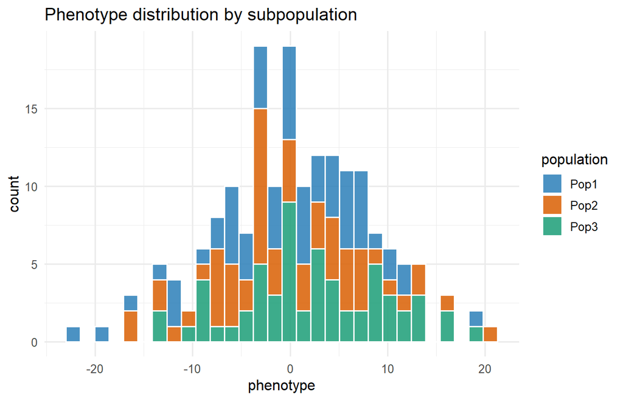

```r
ggplot(data.frame(pheno, pops), aes(pheno, fill = pops)) +
  geom_histogram(bins = 30, alpha = .85, colour = "white") +
  scale_fill_manual(values = pal) +
  labs(title = "Phenotype distribution by subpopulation",
       x = "phenotype", y = "count", fill = "population")
```

## Allele-frequency spectrum

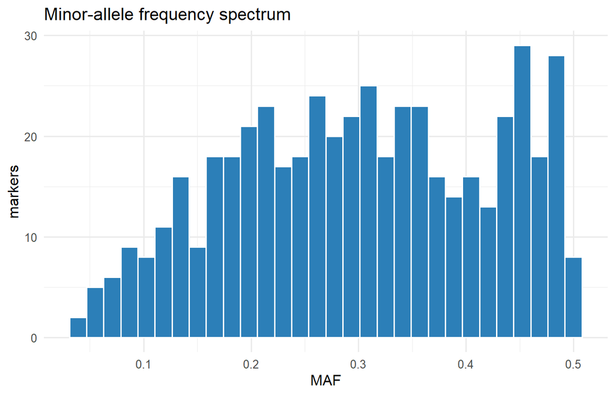

```r
p <- colMeans(geno) / 2
ggplot(data.frame(maf = pmin(p, 1 - p)), aes(maf)) +
  geom_histogram(bins = 30, fill = "#2c7fb8", colour = "white") +
  labs(title = "Minor-allele frequency spectrum", x = "MAF", y = "markers")
```

# 2. Genomic relationship matrix

`Gmatrix()` computes the VanRaden relationship between every pair of individuals. Ordering rows/columns by clustering reveals the block structure of the three subpopulations.

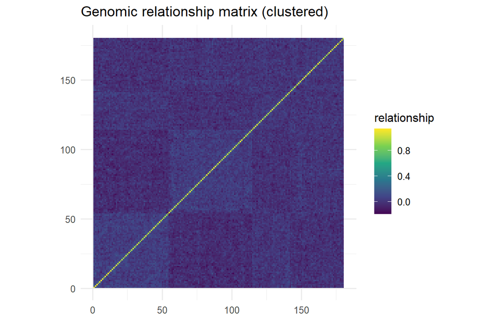

```r
G   <- Gmatrix(geno)
ord <- hclust(dist(G))$order
Go  <- G[ord, ord]
df  <- expand.grid(i = 1:n, j = 1:n); df$rel <- as.vector(Go)
ggplot(df, aes(i, j, fill = rel)) +
  geom_raster() + coord_equal() +
  scale_fill_viridis_c(option = "D") +
  labs(title = "Genomic relationship matrix (clustered)",
       x = NULL, y = NULL, fill = "relationship")
```

# 3. Population structure

## PCA of the markers

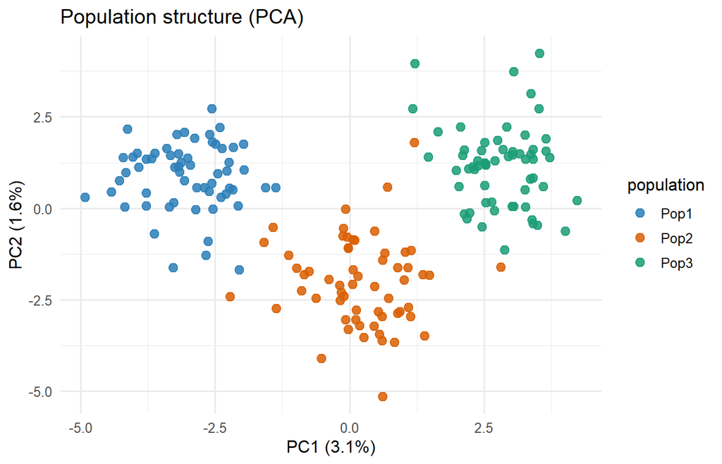

```r
pc <- prcomp(geno, scale. = FALSE)
ve <- pc$sdev^2 / sum(pc$sdev^2)
ggplot(data.frame(PC1 = pc$x[, 1], PC2 = pc$x[, 2], pops),
       aes(PC1, PC2, colour = pops)) +
  geom_point(size = 2.6, alpha = .85) +
  scale_colour_manual(values = pal) +
  labs(title = "Population structure (PCA)",
       x = sprintf("PC1 (%.1f%%)", 100 * ve[1]),
       y = sprintf("PC2 (%.1f%%)", 100 * ve[2]), colour = "population")
```

## Clustering dendrogram

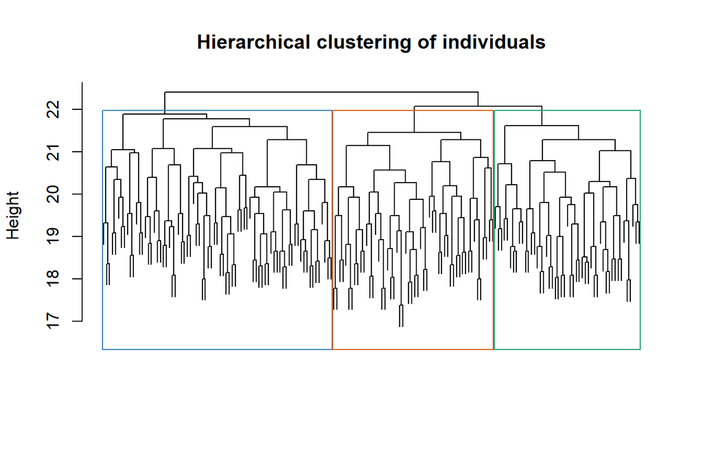

```r
hc <- hclust(dist(geno))
plot(hc, labels = FALSE, main = "Hierarchical clustering of individuals",
     xlab = "", sub = "")
rect.hclust(hc, k = 3, border = unname(pal))
```

# 4. GBLUP

Fit GBLUP by REML on a training set, holding out 45 individuals to test prediction.

```r
set.seed(2)
test  <- sample(n, 45); train <- setdiff(1:n, test)
fit   <- gblup(pheno[train], geno = geno[train, ])
```

## Variance components and heritability

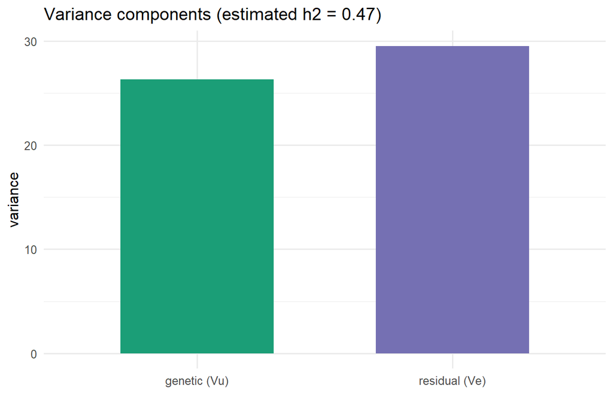

```r
vc <- data.frame(component = c("genetic (Vu)", "residual (Ve)"),
                 value = c(fit$Vu, fit$Ve))
ggplot(vc, aes(component, value, fill = component)) +
  geom_col(width = .6) +
  scale_fill_manual(values = c("#1b9e77", "#7570b3"), guide = "none") +
  labs(title = sprintf("Variance components (estimated h2 = %.2f)", fit$h2),
       x = NULL, y = "variance")
```

## Predicted vs observed (test set)

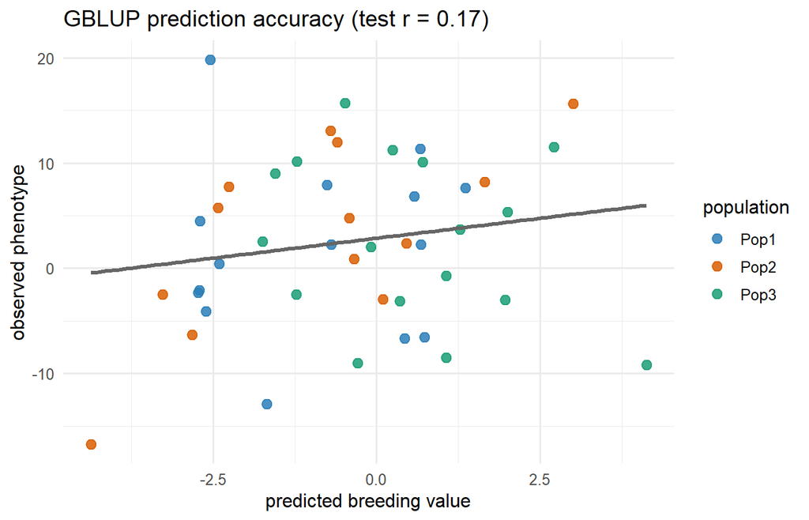

```r
pred <- predict(fit, geno[test, ])
r    <- cor(pred, pheno[test])
ggplot(data.frame(pred, obs = pheno[test], pop = pops[test]),
       aes(pred, obs, colour = pop)) +
  geom_point(size = 2.6, alpha = .85) +
  geom_smooth(method = "lm", se = FALSE, colour = "grey40") +
  scale_colour_manual(values = pal) +
  labs(title = sprintf("GBLUP prediction accuracy (test r = %.2f)", r),
       x = "predicted breeding value", y = "observed phenotype", colour = "population")
```

## Where the signal is: marker effects

The equivalent ridge-regression marker effects highlight the causal QTL.

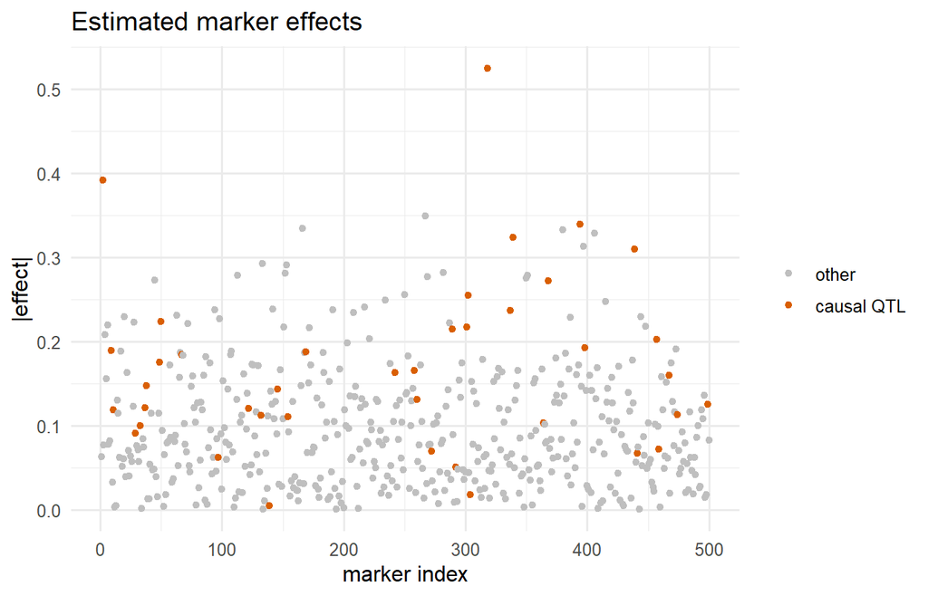

```r
me <- data.frame(idx = seq_along(fit$marker_effects),
                 eff = abs(fit$marker_effects),
                 causal = seq_along(fit$marker_effects) %in% qtl)
ggplot(me, aes(idx, eff, colour = causal)) +
  geom_point(size = 1.4) +
  scale_colour_manual(values = c(`FALSE` = "grey75", `TRUE` = "#d95f02"),
                      labels = c("other", "causal QTL")) +
  labs(title = "Estimated marker effects", x = "marker index",
       y = "|effect|", colour = NULL)
```

## Breeding values by subpopulation

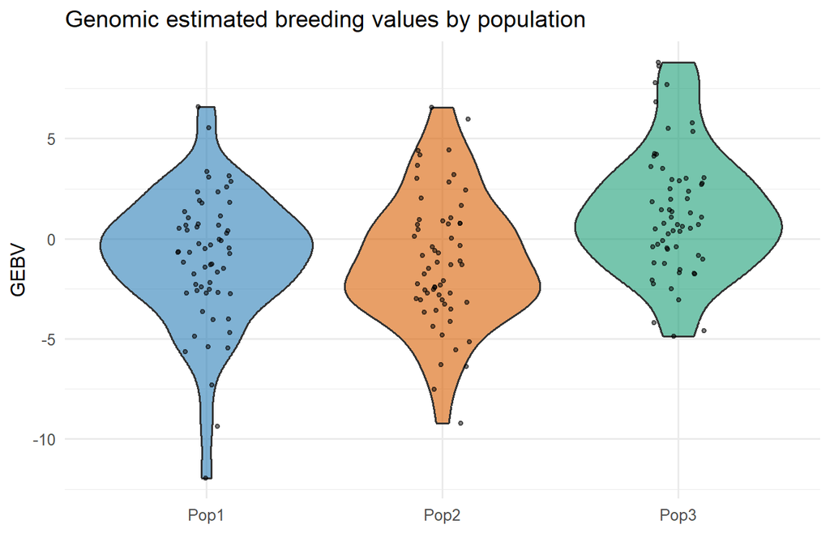

```r
gebv_all <- predict(fit, geno)
ggplot(data.frame(gebv = gebv_all, pops), aes(pops, gebv, fill = pops)) +
  geom_violin(alpha = .6) +
  geom_jitter(width = .12, size = 1, alpha = .5) +
  scale_fill_manual(values = pal, guide = "none") +
  labs(title = "Genomic estimated breeding values by population",
       x = NULL, y = "GEBV")
```

# 5. Comparing models by cross-validation

```r
cv <- gs_cv(pheno, geno,
            models = c("gblup", "elastic_net", "random_forest", "xgboost"),
            k = 5, seed = 1)
s  <- as.data.frame(summary(cv))
```

```
<gs_cv: kfold>
  5-fold x 1 rep(s)
         model  mean    sd n_folds
 random_forest 0.225 0.171       5
         gblup 0.202 0.182       5
       xgboost 0.083 0.214       5
   elastic_net 0.072 0.080       4
  (accuracy = predictive ability, cor(pred, observed) on held-out data)
```

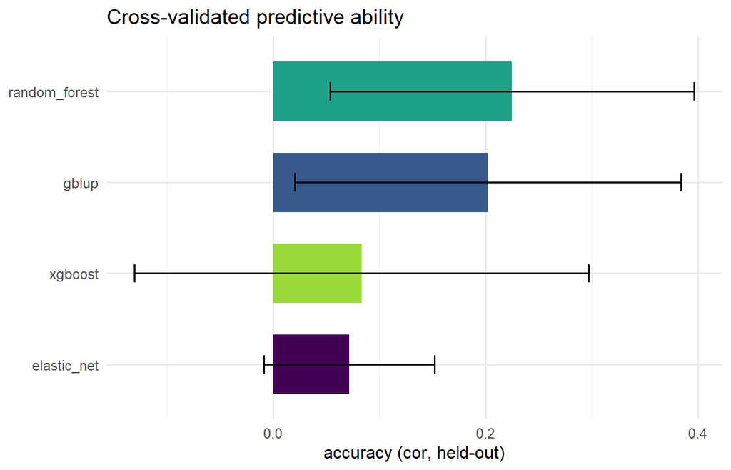

```r
ggplot(s, aes(reorder(model, mean), mean, fill = model)) +
  geom_col(width = .65) +
  geom_errorbar(aes(ymin = mean - sd, ymax = mean + sd), width = .2) +
  coord_flip() +
  scale_fill_viridis_d(option = "D", end = .85, guide = "none") +
  labs(title = "Cross-validated predictive ability",
       x = NULL, y = "accuracy (cor, held-out)")
```

# 6. Stacked ensemble

```r
ens <- gs_ensemble(pheno[train], geno[train, ], seed = 1)
pe  <- predict(ens, geno[test, ])
sprintf("Ensemble test accuracy: %.3f", cor(pe, pheno[test]))
```

```
[1] "Ensemble test accuracy: 0.083"
```

# Summary

You have now seen, visually, the full GSbench workflow: the data and its structure, the genomic relationship matrix, GBLUP variance components and predictions, where the causal signal sits, breeding values by group, and an honest model comparison by cross-validation.

See the [GSbench documentation](https://mqfarooqi1.github.io/GSbench/) for details, and `examples/GSbench_demo.R` for a plain-script version.